# test julia thing

2021-06-18

## newton method

This documents the timings of a simple newton method in R, C (technically cpp but it’s all just C code), and julia.

### the function used

The function is $f_0(x)=e^x+\sin(x)$ so the newton update would be
$$x\leftarrow x-\frac{f_0(x)}{f_1(x)}=x-\frac{e^x+sin(x)}{e^x+cos(x)}$$

applied repeatedly. A graph of the curve is shown below. It’s already fairly linear so the function will hit the root very quickly but that’s ok.

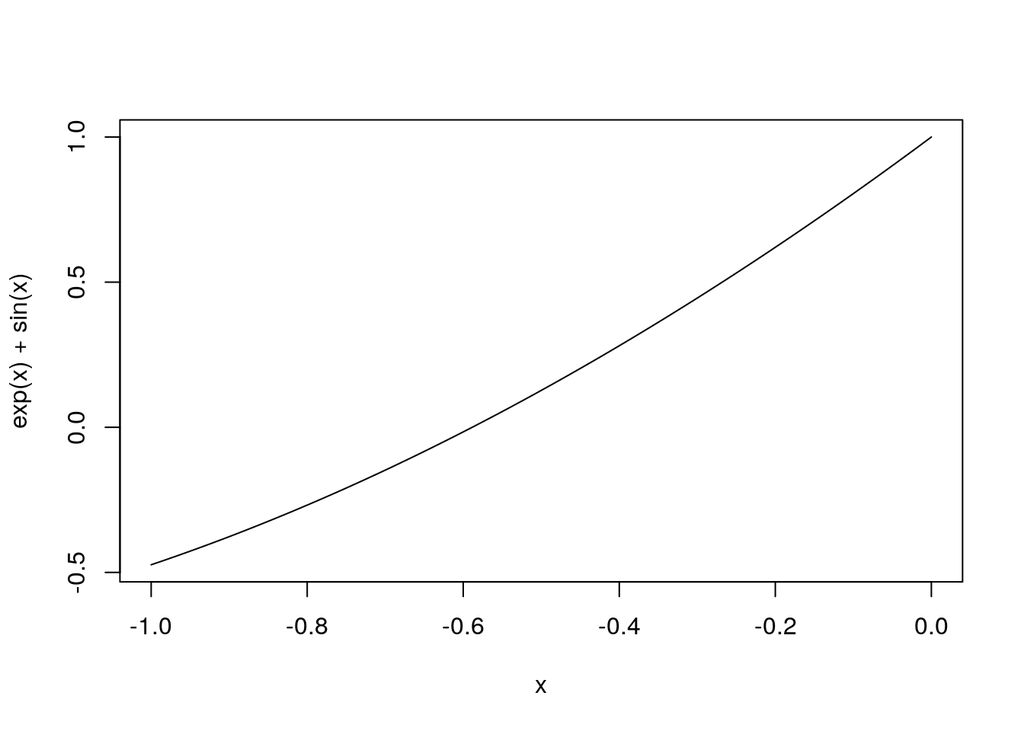

```r
curve(exp(x)+sin(x),-1,0)
```

## the code

We’ll run the code a fixed number of iterations. I don’t know if hitting 0 in the numerator does any short-cutting in any language but thats ok for now.

Note that the julia code will be called within r (just like the rcpp is). For completeness the pure julia code is in the raw julia code .

```r
getroot_r=function(){
  x=0.0
  ee=0
  for (i in 1:50000){
    ee=exp(x)
    x=x-(ee+sin(x))/(ee+cos(x))
  }
  return (x);
}
```

```cpp
#include <Rcpp.h>
using namespace Rcpp;

//[[Rcpp::export]]
double getroot_cpp() {
  double x=0.0;
  double ee=0.0;
  for(int i=0;i<50000;i++){
    ee=exp(x);
    x=x-(ee+sin(x))/(ee+cos(x));
  }
  return (x);
}
```

```r
library(JuliaCall)
julia_command("f0(x)=exp(x)+sin(x)")
```

```
## Julia version 1.6.0 at location /opt/julia-1.6.0/bin will be used.
```

```
## Loading setup script for JuliaCall...
```

```
## Finish loading setup script for JuliaCall.
```

```
## f0 (generic function with 1 method)
```

```r
julia_command("f1(x)=exp(x)+cos(x)")
```

```
## f1 (generic function with 1 method)
```

```r
julia_command("update(x)=x-f0(x)/f1(x)")
```

```
## update (generic function with 1 method)
```

```r
julia_command("function getroot_julia()
    x=0.0
    for i in 1:50000
        x=update(x)
    end
    return x
end")
```

```
## getroot_julia (generic function with 1 method)
```

## results

Now that all the functions are created and available, they’re assessed in R. Each runs the same number of iterations with the same initial guess. Each language’s implementation is run a few times times.

```r
library(microbenchmark)
results = microbenchmark(getroot_r(),getroot_cpp(),julia_eval("getroot_julia()"),times=5)
```

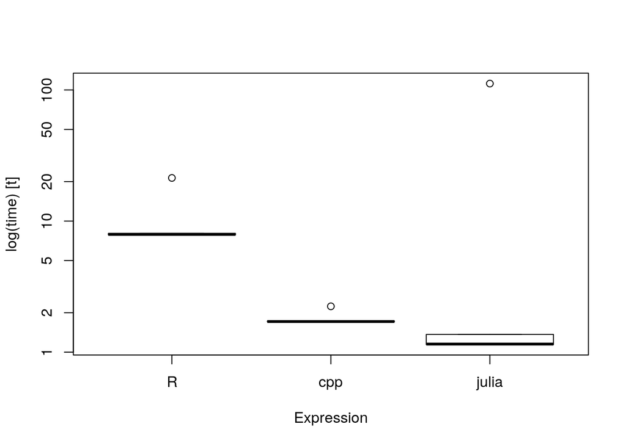

```r
languages = c("R","cpp","julia")
boxplot(results,names=languages)
```

[figure not shown]

```r
library(ggplot2)
languages = c("R","cpp","julia")
df=results
df$expr=languages
autoplot(df)
```

```r
print(results)
```

```
## Unit: milliseconds
##                           expr      min       lq      mean   median       uq
##                    getroot_r() 7.832969 7.855821 10.594492 7.912397 8.048489
##                  getroot_cpp() 1.706731 1.711961  1.818703 1.713119 1.723968
##  julia_eval("getroot_julia()") 1.143226 1.143239 23.326994 1.153697 1.366695
##         max neval
##   21.322783     5
##    2.237735     5
##  111.828111     5
```

```r
medians = summary(results)[,"median"]
names(medians)=languages

#speeds relative to r
medians/max(medians)
```

```
##         R       cpp     julia
## 1.0000000 0.2165107 0.1458088
```

```r
#speeds relative to julia
medians/min(medians)
```

```
##        R      cpp    julia
## 6.858297 1.484895 1.000000
```

## the raw julia code

The raw julia is shown below. These lines are actually run in julia but at the end we’ll call it from R, so the code will be revisted at the end.

```julia
f0(x)=exp(x)+sin(x)
```

```
## f0 (generic function with 1 method)
```

```julia
f1(x)=exp(x)+cos(x)
```

```
## f1 (generic function with 1 method)
```

```julia
update(x)=x-f0(x)/f1(x)
```

```
## update (generic function with 1 method)
```

```julia
function getroot_julia()
  x=0.0
    for i in 1:50000
        x=update(x)
    end
    return x
end
```

```
## getroot_julia (generic function with 1 method)
```

```julia
using BenchmarkTools
timing_julia = @benchmark getroot_julia() samples=5 evals=5
```

```
## BenchmarkTools.Trial:
##   memory estimate:  0 bytes
##   allocs estimate:  0
##   --------------
##   minimum time:     1.021 ms (0.00% GC)
##   median time:      1.033 ms (0.00% GC)
##   mean time:        1.036 ms (0.00% GC)
##   maximum time:     1.071 ms (0.00% GC)
##   --------------
##   samples:          5
##   evals/sample:     5
```

```julia
print(timing_julia)
```

```
## Trial(1.021 ms)
```